```python
# Project: Classify Breast Cancer using SVM

import numpy as np
import pandas as pd
import seaborn as sns
from sklearn.datasets import load_breast_cancer
from sklearn.model_selection import train_test_split
from sklearn.svm import SVC, LinearSVC
from sklearn.metrics import classification_report, confusion_matrix, plot_confusion_matrix
from sklearn.decomposition import PCA
from sklearn.preprocessing import StandardScaler
import matplotlib.pyplot as plt

#magic function for plots in Jupyter NB
%matplotlib inline
```

Let's first load the breast cancer dataset provided by the University of Wisconsin. Features are computed from a digitized image of a fine needle aspirate (FNA) of a breast mass. They describe characteristics of the cell nuclei present in the image.

```python
#Load breast cancer data from University of Wisconsin
(X, y) = load_breast_cancer(return_X_y=True, as_frame=True) # as_frame argument provides data as Pandas dataframe
```

### Exploring the dataset

Now that the data is loaded, we can explore it.

```python
X.shape # Size of the input dataframe
```

```
(569, 30)
```

```python
X.head()
```

|  | mean radius | mean texture | mean perimeter | mean area | mean smoothness | mean compactness | mean concavity | mean concave points | mean symmetry | mean fractal dimension | ... | worst radius | worst texture | worst perimeter | worst area | worst smoothness | worst compactness | worst concavity | worst concave points | worst symmetry | worst fractal dimension |
| --- | --- | --- | --- | --- | --- | --- | --- | --- | --- | --- | --- | --- | --- | --- | --- | --- | --- | --- | --- | --- | --- |
| 0 | 17.99 | 10.38 | 122.80 | 1001.0 | 0.11840 | 0.27760 | 0.3001 | 0.14710 | 0.2419 | 0.07871 | ... | 25.38 | 17.33 | 184.60 | 2019.0 | 0.1622 | 0.6656 | 0.7119 | 0.2654 | 0.4601 | 0.11890 |
| 1 | 20.57 | 17.77 | 132.90 | 1326.0 | 0.08474 | 0.07864 | 0.0869 | 0.07017 | 0.1812 | 0.05667 | ... | 24.99 | 23.41 | 158.80 | 1956.0 | 0.1238 | 0.1866 | 0.2416 | 0.1860 | 0.2750 | 0.08902 |
| 2 | 19.69 | 21.25 | 130.00 | 1203.0 | 0.10960 | 0.15990 | 0.1974 | 0.12790 | 0.2069 | 0.05999 | ... | 23.57 | 25.53 | 152.50 | 1709.0 | 0.1444 | 0.4245 | 0.4504 | 0.2430 | 0.3613 | 0.08758 |
| 3 | 11.42 | 20.38 | 77.58 | 386.1 | 0.14250 | 0.28390 | 0.2414 | 0.10520 | 0.2597 | 0.09744 | ... | 14.91 | 26.50 | 98.87 | 567.7 | 0.2098 | 0.8663 | 0.6869 | 0.2575 | 0.6638 | 0.17300 |
| 4 | 20.29 | 14.34 | 135.10 | 1297.0 | 0.10030 | 0.13280 | 0.1980 | 0.10430 | 0.1809 | 0.05883 | ... | 22.54 | 16.67 | 152.20 | 1575.0 | 0.1374 | 0.2050 | 0.4000 | 0.1625 | 0.2364 | 0.07678 |

5 rows × 30 columns

```python
X.isnull().sum()
```

```
mean radius                0
mean texture               0
mean perimeter             0
mean area                  0
mean smoothness            0
mean compactness           0
mean concavity             0
mean concave points        0
mean symmetry              0
mean fractal dimension     0
radius error               0
texture error              0
perimeter error            0
area error                 0
smoothness error           0
compactness error          0
concavity error            0
concave points error       0
symmetry error             0
fractal dimension error    0
worst radius               0
worst texture              0
worst perimeter            0
worst area                 0
worst smoothness           0
worst compactness          0
worst concavity            0
worst concave points       0
worst symmetry             0
worst fractal dimension    0
dtype: int64
```

There are 30 attributes and 569 instances. None of the data points is missing and the data set is complete. The dataset that we can find in scikit-learn has already been cleaned. The original dataset in the UCI repository instead included some missing data.

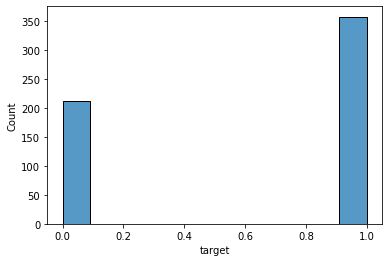

```python
# Visualize distribution of the target variable
# 0 = malignant cancer
# 1 = bening cancer

sns.histplot(y)
```

```python
y.isnull().sum()
```

```
0
```

Let's now produce some pairplots to understand the high level relationship between features. In this case we only plot the first 8 features as an example.

```python
pairplot_vars = ['mean radius', 'mean texture', 'mean perimeter',
                 'mean area', 'mean smoothness', 'mean compactness',
                 'mean concavity', 'mean symmetry']
```

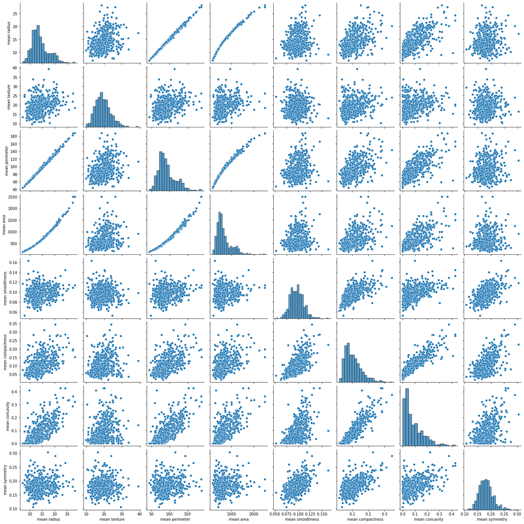

```python
sns.pairplot(X, vars=pairplot_vars)
```

As we can seen in the plot above, many features are linearly correlated. We can improve the plot by adding some coloring to identify the data points relative to the 2 target classes.

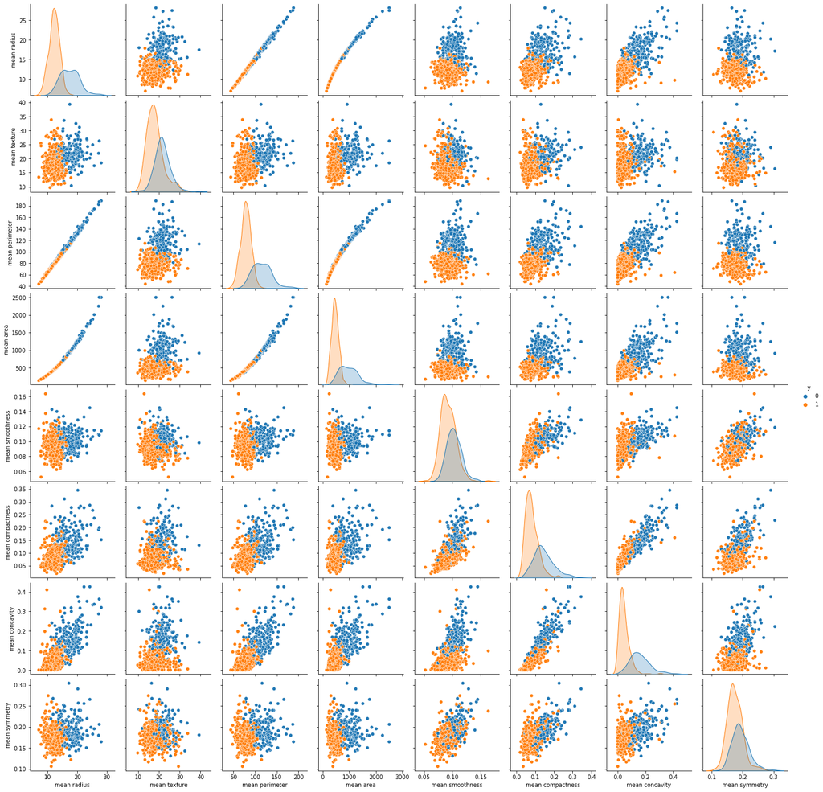

```python
df = pd.merge(X, y.rename('y'), left_index=True, right_index=True) #merge input and output into 1 df
sns.pairplot(df, hue='y', vars=pairplot_vars)
```

From the pair scatterplots above, we can notice that the this dataset presents the potential of being separable. We will investigate in the next steps how to exploit this characteristic.

Another way to verify whether some features are linearly correlated is to prepare a heatmap of the correlation matrix. This is shown in the steps below.

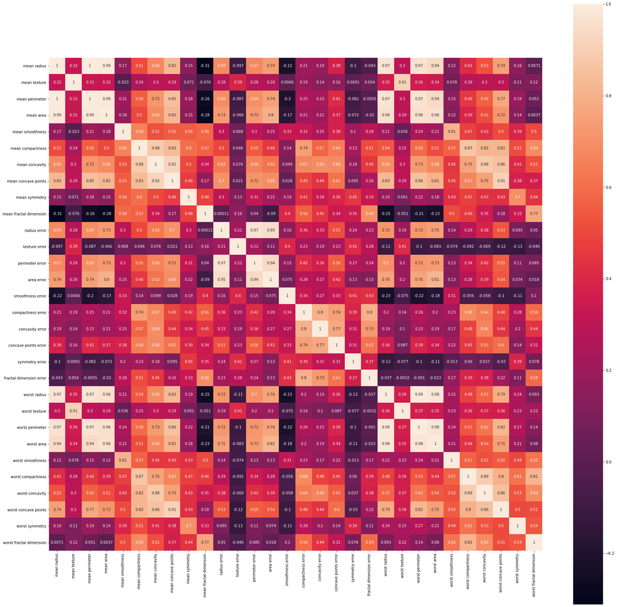

```python
plt.figure(figsize=(30,30))
sns.heatmap(X.corr(), annot=True, square=True)
```

### Preparing the data to train the model

After exploring some of the data characteristics, we are ready to prepare our dataset to train our machine learning algorithm. In this case we chose to split the dataset with an 80/20 ratio for train and test. This ratio is quite common in machine learning. We also set the seed to a fixed number to provide reproducibility.

```python
#Split data into train and test set (80-20)
X_train, X_test, y_train, y_test = train_test_split(X, y, test_size = .2, shuffle=True, random_state = 77)
```

```python
cnt = y_train.value_counts()
print(f'Train set target ratio: {cnt[0]/cnt[1]}')
```

```
Train set target ratio: 0.6134751773049646
```

```python
cnt = y_test.value_counts()
print(f'Test set target ratio: {cnt[0]/cnt[1]}')
```

```
Test set target ratio: 0.52
```

As we can see above, the resulting train and test sets are not balanced. The ratio between target classes is different (61% vs 52%). This might be an issue for the training of the model, so we decide to utilize the 'stratify' option provided by scikit-learn.

```python
#Split data into train and test set (80-20) with STRATIFICATION
X_train, X_test, y_train, y_test = train_test_split(X, y, test_size = .2,
                                                    shuffle=True, random_state = 77,
                                                    stratify=y)
```

```python
cnt = y_train.value_counts()
print(f'Train set target ratio: {cnt[0]/cnt[1]}')
```

```
Train set target ratio: 0.5964912280701754
```

```python
cnt = y_test.value_counts()
print(f'Test set target ratio: {cnt[0]/cnt[1]}')
```

```
Test set target ratio: 0.5833333333333334
```

After the split with stratification, the ratio of the target classes in the train and test datasets now is closer.

### Classification using Support Vector Machine (SVM)

At this point, we are ready to train our model. We choose to utilize a Support Vector Machine (SVM) for this project. SVM is a good option when the target is binary as in this case.

```python
# SVM model with Radial Basis Function kernel
clf = SVC() # By default, kernel='RBF'
clf.fit(X_train, y_train)

# Make predictions on test set
y_pred = clf.predict(X_test)

# Calculate classification accuracy
score_train = clf.score(X_train, y_train)
score_test = clf.score(X_test, y_test)
print(f"SVM train score: {score_train} | test score: {score_test}")
```

```
SVM train score: 0.9230769230769231 | test score: 0.9122807017543859
```

With the default kernel (Radial Basis Function), we can already obtain a good score (91%). We can also plot the confusion matrix to check how many examples our model couldn't classify correctly.

```python
confusion_matrix(y_test, y_pred)
```

```
array([[34,  8],
       [ 2, 70]], dtype=int64)
```

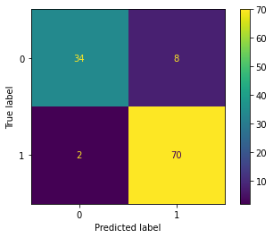

```python
plot_confusion_matrix(clf, X_test, y_test)
plt.grid(False)
```

Scikit-learn provides many different metrics to evaluate the model. One example is the classification report, that shows precision, recall, accuracy and other useful metrics.

```python
print(classification_report(y_test, y_pred))
```

```
              precision    recall  f1-score   support

           0       0.94      0.81      0.87        42
           1       0.90      0.97      0.93        72

    accuracy                           0.91       114
   macro avg       0.92      0.89      0.90       114
weighted avg       0.91      0.91      0.91       114
```

One can also easily plot the precision-recall curve for this model.

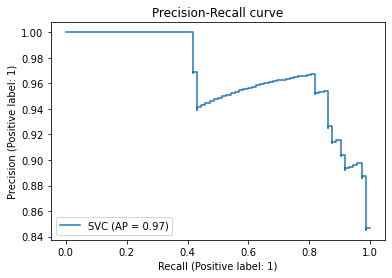

```python
from sklearn.metrics import plot_precision_recall_curve

disp = plot_precision_recall_curve(clf, X_test, y_test)
disp.ax_.set_title('Precision-Recall curve')
```

Let's see now if we can improve the model performance. When we explored the data, from the scatterplots we noticed that most of the features could be linearly separated to provide information towards the target variable. We can see if this intuition can be used to improve the performance, and thus use a linear kernel to train the SVM model.

```python
# SVM model with linear kernel
clf = SVC(kernel='linear')
clf.fit(X_train, y_train)

# Make predictions on test set
y_pred = clf.predict(X_test)

# Calculate classification accuracy
score_train = clf.score(X_train, y_train)
score_test = clf.score(X_test, y_test)
print(f"SVM train score: {score_train} | test score: {score_test}")
```

```
SVM train score: 0.9692307692307692 | test score: 0.956140350877193
```

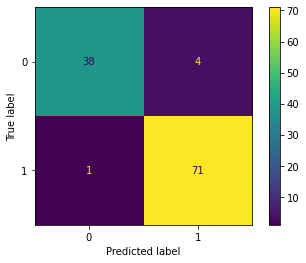

```python
plot_confusion_matrix(clf, X_test, y_test)
plt.grid(False)
```

Using a linear kernel, our test score improved by more than 4% to 95.6%. We can see that the train score is higher than the test score (96.9% vs 95.6%). This denotes some overfitting to the train data. In the next section, we can see if we can improve this.

### Dimensionality reduction with Principal Component Analysis (PCA)

Using Principal Component Analysis (PCA), we can check if some of the input features are more important than others (i.e. if they carry more information).

```python
scaler = StandardScaler()
X_scaled = scaler.fit_transform(X)
```

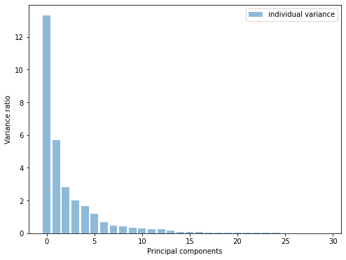

```python
# Principal Component Analysis
pca = PCA()
pca.fit_transform(X_scaled)
pca_variance = pca.explained_variance_

# Visualize principal components
plt.figure(figsize=(8, 6))
plt.bar(range(len(pca_variance)), pca_variance, alpha=0.5, align='center', label='individual variance')
plt.legend()
plt.ylabel('Variance ratio')
plt.xlabel('Principal components')
plt.show()
```

```python
# Explained variance ratio of first 16 components
sum(pca_variance[0:16])/sum(pca_variance)
```

```
0.9891502160796992
```

As we can see above, the first 16 components already provide almost 99% of all the variance. The remaining 14 components do not bring any new information, because they are lowly correlated to the output or because they are linearly correlated with other input features. We can thus keep only the first 16 components of the dataset and discard the rest. This way we eliminated almost half of the input data that is not strictly needed.

```python
pca = PCA(n_components=16)
X_reduced = pca.fit(X_scaled).transform(X_scaled)
```

```python
#Split data into train and test set (80-20) with STRATIFICATION
X_train_reduced, X_test_reduced, y_train, y_test = train_test_split(X_reduced, y, test_size = .2,
                                                    shuffle=True, random_state = 77,
                                                    stratify=y)
```

```python
# SVM model with linear kernel
clf = SVC(kernel='linear')
clf.fit(X_train_reduced, y_train)

# Make predictions on test set
y_pred = clf.predict(X_test_reduced)

# Calculate classification accuracy
score_train = clf.score(X_train_reduced, y_train)
score_test = clf.score(X_test_reduced, y_test)
print(f"SVM train score: {score_train} | test score: {score_test}")
```

```
SVM train score: 0.9846153846153847 | test score: 0.9824561403508771
```

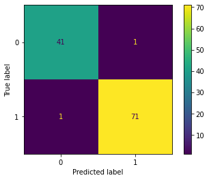

```python
plot_confusion_matrix(clf, X_test_reduced, y_test)
plt.grid(False)
```

```python
print(classification_report(y_test, y_pred))
```

```
              precision    recall  f1-score   support

           0       0.98      0.98      0.98        42
           1       0.99      0.99      0.99        72

    accuracy                           0.98       114
   macro avg       0.98      0.98      0.98       114
weighted avg       0.98      0.98      0.98       114
```

After retraining the SVM model with the reduced and normalized dataset, the performance is greatly improved. Both the train and test score are 98% denoting practically no overfitting to the train data. The confusion matrix shows that only 2 examples (1 per category) are misclassified out of a total of 114.